# {{ page.title }}

### 3C. Checking for Outliers

Sometimes a jackknife can produce mixed fourth moments that are ‘outliers’ - when a specific block of SNPs is excluded in one jackknife, the estimates are much different than the estimates from other jackknifes. This can be checked for by making a scatter plot:

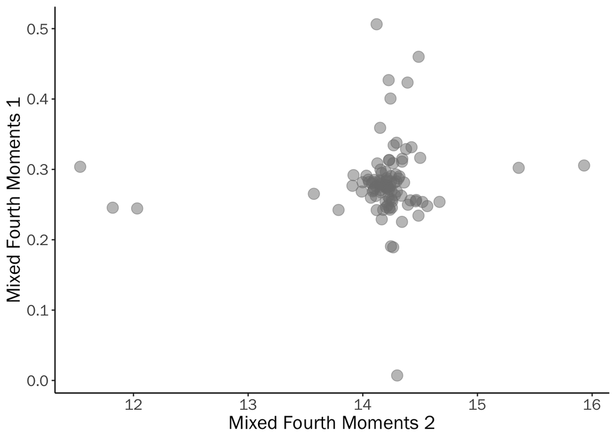

```r
# Check for outlier blocks
jackknifedf <- as.data.frame(jackknife)
jackknifedf$colour <- NA

# Plot
ggplot(jackknifedf, aes(x=jackknifedf[,2], y=jackknifedf[,3], colour=colour))+
  geom_point(size=4, alpha=0.5)+
  theme+
  ylab("Mixed Fourth Moments 1")+ xlab("Mixed Fourth Moments 2")+
  guides(colour="none")+
  theme(text = element_text(size = 16))
```

From the scatter plot, we can see that there are not any massive outliers. If there were any outliers, the jackknife blocks these correspond to could be removed to check if they affect the overall results.

### 3D. Genetic Correlation

It is good to check that the genetic correlation estimate from LCV is somewhat similar to the estimate from LDSC. These values won’t be exactly the same as LCV and LDSC use slightly different methods to estimate genetic correlation, and we are using a smaller set of SNPs.

```r
# Get mean rho for rho estimate (genetic correlation)
rho.est <- mean(jackknife[,1])

# Get rho standard error for rho estimate (genetic correlation)
rho.err <- sd(jackknife[,1])*sqrt(nBlocks+1)
flip <- sign(rho.est)

message('Genetic correlation: ', round(rho.est, 4), ' (', round(rho.err, 4),')')
```

```
## Genetic correlation: 0.1239 (0.0233)
```

The genetic correlation estimate from LCV is 0.12, which is very similar to the LDSC estimate of 0.11.

## 4. Estimating the gcp Value

### 4A. Computing gcp Likelihoods

Now we have our mixed fourth moments, we can compute the likelihood of each specific gcp value. The function below, from github.com/lukejoconnor/LCV, does this:

```r
# Get mixed fourth moments
jackknife[,2:3] <- jackknife[,2:3]-3*jackknife[,1]

# Get dataframe corresponding to all possible gcp values
gcp.likelihood.trigbps <- grid
gcp.likelihood.trigbps[] <- 0

# For each value in the gcp grid get the likelihood
for(kk in 1:length(grid)){

  # Compute likelihood
  xx <- grid[kk]
  fx <- abs(jackknife[,1])^(-xx)
  numer <- jackknife[,2]/fx-fx*jackknife[,3]
  denom <- pmax(1/abs(jackknife[,1]), sqrt(jackknife[,2]^2/fx^2+ jackknife[,3]^2*fx^2))
  pct.diff <- numer/denom
  gcp.likelihood.trigbps[kk] <- dt(mean(pct.diff)/sd(pct.diff)/sqrt(nBlocks+1), nBlocks-2)

  # Get p-value when gcp=1 and gcp=-1
  if(xx==-1){pval.fullycausal.2 <- pt(-flip*mean(pct.diff)/sd(pct.diff)/sqrt(nBlocks+1),nBlocks-2)}
  if(xx==1){pval.fullycausal.1 <- pt(flip*mean(pct.diff)/sd(pct.diff)/sqrt(nBlocks+1),nBlocks-2)}

  # Get zscore when gcp=0 (tests whether gcp is different from 0)
  if(xx==0){zscore <- flip*mean(pct.diff)/sd(pct.diff)/sqrt(nBlocks+1)}

}
```

### 4B. Inspecting gcp Likelihoods

To inspect the computed likelihood estimates for each gcp value, we can create a heatmap as follows:

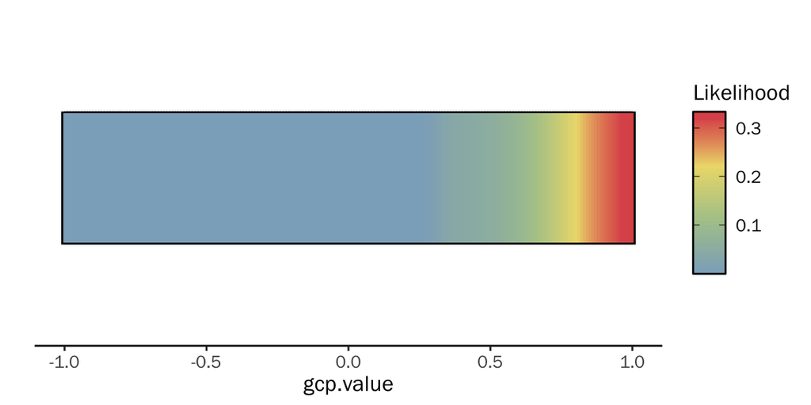

```r
# gcp likelihood dataframe
gcp.likelihood.trigbps.df <- data.frame(gcp.likelihood.trigbps)
gcp.likelihood.trigbps.df$gcp.value <- (-100:100)/100

# Plot
ggplot(gcp.likelihood.trigbps.df, aes(x = gcp.value, y = 0.5, fill = gcp.likelihood.trigbps))+
  geom_tile(color="black", size=1)+
  geom_tile(fill='white')+
  geom_tile(alpha=0.75)+
  ylab("")+
  theme+
  scale_fill_gradientn(colours=colorRampPalette(c('#5f8fb0', '#93b572', '#e7d044', '#d10000'))(100),
                       na.value='#5f8fb0',
                       guide=guide_colorbar(frame.colour="black",
                                            ticks.colour="black",
                                            alpha=0.75,
                                            title='Likelihood'))+
  scale_y_discrete(expand=(c(0,0.8)))
```

### 4C. Computing the gcp Estimate

From the heatmap, we can see that it is much more likely that the gcp value is nearer 1 than near -1. To get a single gcp estimate, we take the mean of all possible gcp values, weighted by their computed likelihood:

```r
# Estimate gcp value: Get mean of all gcp values (weighted by likelihood)
gcp.pm.trigbps <- WeightedMean(grid, gcp.likelihood.trigbps)

# Estimate gcp value: estimate standard error
gcp.pse.trigbps <- sqrt(WeightedMean(grid^2, gcp.likelihood.trigbps)-gcp.pm.trigbps^2)

# Print
message('gcp estimate: ', round(gcp.pm.trigbps, 2), ' (', round(gcp.pse.trigbps, 2),')')
```

```
## gcp estimate: 0.79 (0.17)
```

A gcp estimate of 0.79 indicates a direction of causality from plasma triglyceride level to systolic blood pressure. In other words, the LCV model predicts that systolic blood pressure is affected by plasma triglyceride level - not the other way around.

### 4D. Looking at Cokurtosis Values

How is the gcp value derived? As a simplified overview, we can look at the cokurtosis estimates for plasma triglyceride level to systolic blood pressure and systolic blood pressure to plasma triglyceride level - roughly, the ratio between the two indicates what direction the gcp estimate might go in (positive or negative):

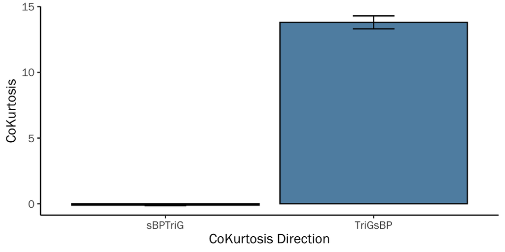

```r
# Create df
df <- data.frame(comparison=c('TriGsBP', 'sBPTriG'),
                 cokurtosis=c(mean(jackknife[,2]), mean(jackknife[,3])),
                 sd=c(sd(jackknife[,2]), sd(jackknife[,3])))

# Plot
ggplot(df, aes(x=comparison, y=cokurtosis))+
  geom_col(fill=c('#5f8fb0', '#93b572'), colour='black', position = position_dodge(width = 0.5))+
  theme +
  xlab('CoKurtosis Direction') + ylab('CoKurtosis') +
  geom_errorbar(aes(ymin = cokurtosis-sd,ymax = cokurtosis+sd), width = 0.2)
```

Here it can be seen that the cokurtosis estimate where plasma triglyceride level is the primary variable is much larger than the cokurtosis estimate where systolic blood pressure is the primary variable. A large difference between these two cokurtosis measures results in a large gcp value (near -1 or 1) - the ratio between these two estimates gives us an idea of how our gcp estimate was derived.

### 4E. Hypothesis Testing

After computing a gcp estimate, we can also perform a test on the null hypothesis that gcp=0:

```r
# Estimate p-value (tests whether gcp is different from 0)
pval.gcpzero.2tailed.trigbps=pt(-abs(zscore),nBlocks-1)*2

# Print
message('P-value: ', formatC(pval.gcpzero.2tailed.trigbps, format = "e", digits = 2))
```

```
## P-value: 4.68e-47
```

A p-value of 4.68e-47 is highly significant, meaning that we can reject the null hypothesis that gcp=0.

### 4F. Heritability

It is also a good idea to check the heritability z-scores for both of the GWAS datasets we used: a z-score below 7 may indicate a trait that is not heritable enough for LCV to work correctly.

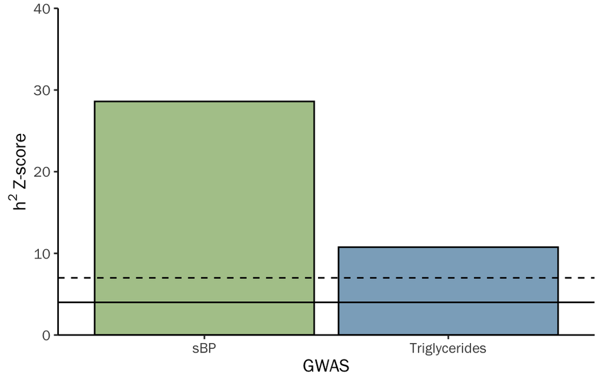

```r
# Get mean z-scores for each GWAS
mean.zscore.1.trig  <-  mean(jackknife[,5])
mean.zscore.2.bps  <-  mean(jackknife[,6])

# Get h2 z-score
h2.zscore.1.trig <- mean(jackknife[,5])/sd(jackknife[,5])/sqrt(nBlocks+1)
h2.zscore.2.bps <- (mean(jackknife[,6])/sd(jackknife[,6]))/sqrt(nBlocks+1)

# Create df
h2.zscores <- data.frame('GWAS'=c('Triglycerides', 'sBP'), 'h2 Z-score'=c(h2.zscore.1.trig, h2.zscore.2.bps))

# Plot
ggplot(h2.zscores, aes(x=GWAS))+
  geom_col(aes(y=h2.Z.score), fill=c('#5f8fb0', '#93b572'), alpha=0.75, colour='black')+
  geom_hline(yintercept=7, colour='black', linetype='dashed')+
  geom_hline(yintercept=4, colour='black', linetype='solid')+
  scale_y_continuous(limits=c(0,40), expand=c(0,0), name=bquote(h^2~`Z-score`))+
  theme
```

The graph indicates that both plasma triglyceride level and systolic blood pressure are heritable enough for the LCV model to work reliably.

## Summary

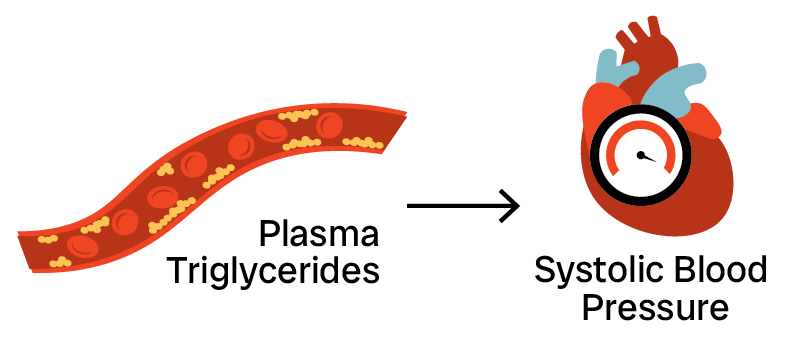

By applying the LCV model to two different GWAS datasets for plasma triglyceride level and systolic blood pressure, we can conclude that plasma triglyceride level is likely to affect systolic blood pressure.